# Probability and Confidence Intervals

Author

Global Health and Infectious Diseases Group - KCCR-KNUST, Ghana for ISARIC

## Probability and Confidence Intervals

In clinical research, we often need to estimate population parameters (like the mean platelet count) from sample data. Two key concepts help us understand and communicate the uncertainty in our estimates:

- **Reference Range**: Describes the **spread of individual values** in the population. It answers: “What values are considered normal?”
- **Confidence Interval (CI)**: Describes the **precision of our estimate** of the population mean. It answers: “Where is the true population mean likely to be?”

These concepts are fundamental to interpreting clinical measurements and study results. Understanding the difference between them is crucial for proper statistical reasoning in clinical research.

## Setting Up the Environment

We’ll use the same synthetic platelet dataset from previous chapters. The `dplyr` package will help us with data manipulation. We’ll convert the platelet variable to numeric and remove any missing values to ensure clean data for analysis.

```r
library(dplyr)
# Load the synthetic dataset
df <- read.csv(
  "https://raw.githubusercontent.com/EstebanGarciaG/Lectures/main/data/data_synth.csv"
)

# Convert platelets to numeric and remove missing values
df$labs_platelets_103ul <- as.numeric(df$labs_platelets_103ul)
df <- df %>% filter(!is.na(labs_platelets_103ul))
```

## Part 1: Reference Range (Describing Individual Value Variability)

### Concept

A **reference range** (also called normal range or reference interval) describes the spread of values for individual observations in the population. It’s typically constructed as:

$$\text{Reference Range} = \text{Mean} \pm 1.96 \times \text{SD}$$

This interval contains approximately 95% of individual values in a normally distributed population. A single patient’s test result is compared against this range to determine if it’s “normal” or abnormal.

**Key Distinction**: The reference range is about **individual values**, not the mean. It’s wider than a confidence interval because it reflects the natural variability in the population.

### Computing the Reference Range

```r
# Calculate population statistics from the full dataset
platelet_mean <- mean(df$labs_platelets_103ul)
platelet_sd <- sd(df$labs_platelets_103ul)

# 95% reference range: mean ± 1.96 * SD
ref_low <- platelet_mean - 1.96 * platelet_sd
ref_high <- platelet_mean + 1.96 * platelet_sd

cat("\n--- Reference Range (Individual Values) ---\n")
```

```
--- Reference Range (Individual Values) ---
```

```r
cat(sprintf("Mean = %.2f, SD = %.2f\n", platelet_mean, platelet_sd))
```

```
Mean = 2.52, SD = 0.81
```

```r
cat(sprintf("95%% reference range: [%.2f, %.2f]\n", ref_low, ref_high))
```

```
95% reference range: [0.93, 4.11]
```

### Checking Individual Values

Once we have the reference range, we can compare a specific observed value to see if it falls within the normal range:

```r
# Take an example observed value from the dataset
obs_value <- df$labs_platelets_103ul[1]

# Check if it falls within the reference range
in_range <- obs_value >= ref_low & obs_value <= ref_high
status <- ifelse(in_range, "INSIDE", "OUTSIDE")

cat(sprintf(
  "Example observed value = %.2f -> %s the 95%% reference range\n",
  obs_value,
  status
))
```

```
Example observed value = 1.55 -> INSIDE the 95% reference range
```

**Warning**

**Clinical Interpretation**: If a patient’s platelet count falls outside this reference range, it may indicate a clinical abnormality (thrombocytopenia if too low, thrombocytosis if too high). However, about 5% of healthy individuals will fall outside the reference range by chance alone.

## Part 2: Confidence Interval (Describing Estimate Precision)

### Concept

A **confidence interval** provides a range of plausible values for an unknown population parameter (like the population mean). The 95% CI means: “If we repeated our sampling process many times, approximately 95% of the intervals we compute would contain the true population mean.”

The formula for a 95% CI for the mean is:

$$\text{95% CI} = \text{Sample Mean} \pm 1.96 \times \text{SE}$$

where $\text{SE} = \frac{\text{SD}}{\sqrt{n}}$ (standard error of the mean)

**Key Distinction**: The confidence interval is about **where the population mean likely is**, not individual values. It gets narrower as sample size increases because larger samples give more precise estimates.

### Computing the Confidence Interval

```r
set.seed(123) # For reproducibility

# Draw a random sample of size n = 50
n <- 50
samp <- sample(df$labs_platelets_103ul, n, replace = FALSE)

# Calculate sample statistics
samp_mean <- mean(samp)
samp_sd <- sd(samp)
samp_se <- samp_sd / sqrt(n)

# Compute 95% confidence interval
ci_low <- samp_mean - 1.96 * samp_se
ci_high <- samp_mean + 1.96 * samp_se

cat("\n--- Confidence Interval (Sample Estimate) ---\n")
```

```
--- Confidence Interval (Sample Estimate) ---
```

```r
cat(sprintf("Sample size n = %d\n", n))
```

```
Sample size n = 50
```

```r
cat(sprintf(
  "Sample mean = %.2f, SD = %.2f, SE = %.3f\n",
  samp_mean,
  samp_sd,
  samp_se
))
```

```
Sample mean = 2.50, SD = 0.76, SE = 0.107
```

```r
cat(sprintf("95%% CI for the mean: [%.2f, %.2f]\n", ci_low, ci_high))
```

```
95% CI for the mean: [2.29, 2.71]
```

**Interpretation**: Based on our sample of 50 patients, we estimate the true population mean platelet count is between 2.29 and 2.71 (10³/µL), with 95% confidence. This tells us how precisely we’ve estimated the population mean.

## Visualization 1: Reference Range Distribution

The histogram below shows the distribution of individual platelet values in the population. The vertical lines indicate the mean (solid) and the 95% reference limits (dashed), which contain 95% of individual observations.

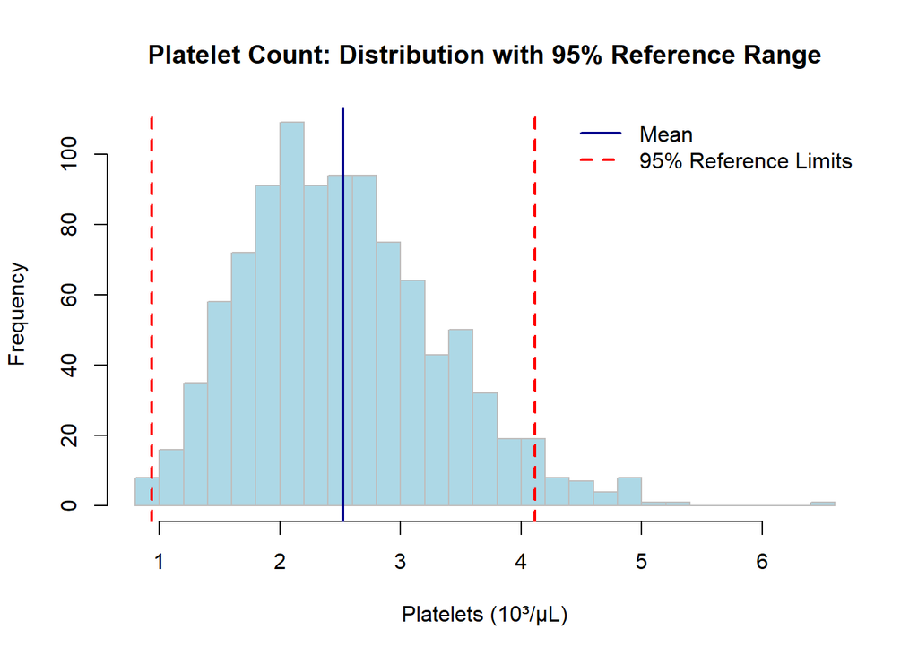

Figure 1: Distribution of platelet counts with 95% reference range limits

```r
hist(
  df$labs_platelets_103ul,
  breaks = 30,
  main = "Platelet Count: Distribution with 95% Reference Range",
  xlab = "Platelets (10³/µL)",
  col = "lightblue",
  border = "gray"
)

# Add lines for mean and reference limits
abline(v = platelet_mean, lwd = 2, col = "darkblue") # Mean
abline(v = ref_low, lty = 2, lwd = 2, col = "red") # 95% ref low
abline(v = ref_high, lty = 2, lwd = 2, col = "red") # 95% ref high

# Add legend
legend(
  "topright",
  legend = c("Mean", "95% Reference Limits"),
  lty = c(1, 2),
  col = c("darkblue", "red"),
  lwd = 2,
  bty = "n"
)
```

## Visualization 2: How Sample Size Affects Confidence Interval Width

As sample size increases, our estimate of the population mean becomes more precise, so the confidence interval becomes narrower. This visualization demonstrates that principle:

### Computing Confidence Intervals at Multiple Sample Sizes

```r
# Prepare data
df$labs_platelets_103ul <- as.numeric(df$labs_platelets_103ul)
df <- df[!is.na(df$labs_platelets_103ul), ]

set.seed(123)

# Sample sizes to compare
n_vec <- c(20, 50, 100, 200, 400)
N <- nrow(df)
n_vec <- n_vec[n_vec <= N] # Only keep sample sizes feasible for our dataset

# Pre-allocate storage for results
k <- length(n_vec)
means <- numeric(k)
ci_lo <- numeric(k)
ci_hi <- numeric(k)

# Reference population mean
platelet_mean <- mean(df$labs_platelets_103ul)

# For each sample size, compute the mean and 95% CI
for (i in seq_along(n_vec)) {
  n <- n_vec[i]
  s <- sample(df$labs_platelets_103ul, n, replace = FALSE)

  # Calculate statistics
  m <- mean(s)
  sd_ <- sd(s)
  se_ <- sd_ / sqrt(n)

  # Store results
  means[i] <- m
  ci_lo[i] <- m - 1.96 * se_
  ci_hi[i] <- m + 1.96 * se_
}
```

**Results Summary**: We’ve computed sample means and 95% confidence intervals for five different sample sizes: 20, 50, 100, 200, and 400. Notice how the confidence intervals become narrower as n increases.

### Plotting Confidence Intervals

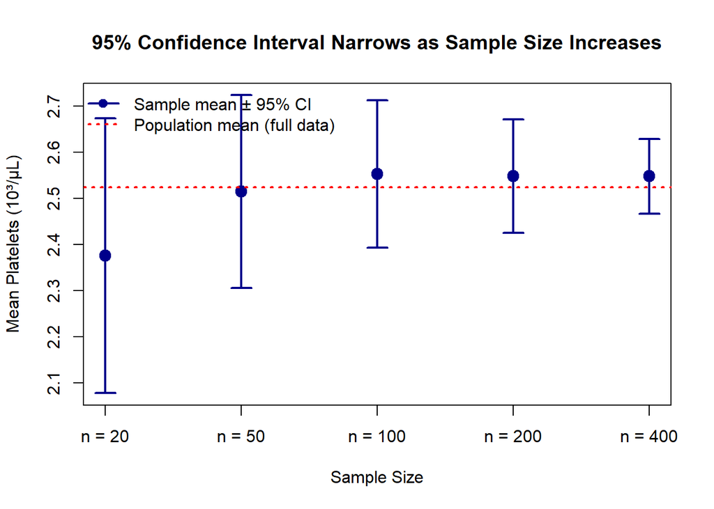

Figure 2: 95% confidence intervals narrow as sample size increases

```r
# Prepare x-axis positions
x <- seq_along(n_vec)

# Create plot with sample means
plot(
  x,
  means,
  ylim = range(c(ci_lo, ci_hi)),
  xaxt = "n",
  xlab = "Sample Size",
  ylab = "Mean Platelets (10³/µL)",
  main = "95% Confidence Interval Narrows as Sample Size Increases",
  pch = 19,
  cex = 1.5,
  col = "darkblue"
)

# Add confidence interval error bars
arrows(
  x0 = x,
  y0 = ci_lo,
  x1 = x,
  y1 = ci_hi,
  angle = 90,
  code = 3,
  length = 0.1,
  lwd = 2,
  col = "darkblue"
)

# Add x-axis labels showing sample sizes
axis(1, at = x, labels = paste0("n = ", n_vec))

# Add horizontal line for true population mean (reference)
abline(h = platelet_mean, lty = 3, lwd = 2, col = "red")

# Add legend
legend(
  "topleft",
  legend = c("Sample mean ± 95% CI", "Population mean (full data)"),
  lty = c(1, 3),
  pch = c(19, NA),
  col = c("darkblue", "red"),
  lwd = c(2, 2),
  bty = "n"
)
```

## Key Takeaways

**WarningReference Range vs. Confidence Interval**

| Concept | Purpose | Based On | Use Case |
| --- | --- | --- | --- |
| **Reference Range** | Describe normal individual values | Population SD | Compare individual patient result to “normal” |
| **Confidence Interval** | Estimate population mean | Sample SE | Report precision of study estimate |

**Remember**: A reference range is wide (encompasses 95% of individual values), while a confidence interval is narrow (reflects our precision in estimating the population mean). Don’t confuse them!

### Why This Matters in Clinical Research

1. **Patient Care**: Use the reference range when deciding if a single patient’s result is abnormal
2. **Research Reporting**: Always report confidence intervals around study estimates to show precision
3. **Sample Size**: Recognize that larger studies give tighter confidence intervals, but still need adequate power
4. **Ethics**: In clinical trials, understand that the precision of your estimate depends on how many participants you include